# Part 1: Spatial Weights, Spatial Autocorrelation, Polygons

This example follows the SciPy 18 Chapter 6 - Exploratory Spatial Data Analysis (ESDA) using Pysal. However, some additional material on contiguity weights is included. The data file is the same Buffalo Open Data file used in the Spatial Processing exercise.

```python
import pandas as pd
import geopandas as gpd
import libpysal as lp
from libpysal.weights import Queen, Rook, KNN, Kernel
import mapclassify as mc
import matplotlib.pyplot as plt
import numpy as np
from pysal.viz import splot
from splot.esda import moran_scatterplot, plot_moran, lisa_cluster
# draw maps in the notebook
%matplotlib inline
```

```python
url_bg = "https://data.buffalony.gov/resource/u7fm-4kwb.geojson?"+\
"$select=the_geom,geoid10,total_pop,white,black,hispanic,hse_units,occup"+\
"&$limit=10000"

bg=gpd.read_file(url_bg)
bg = bg.to_crs('epsg:3857')
bg['area_o']= bg['geometry'].area/10**6 #sq kilometers
bg=bg.apply(pd.to_numeric, errors='ignore')
bg.shape[0]
```

```
287
```

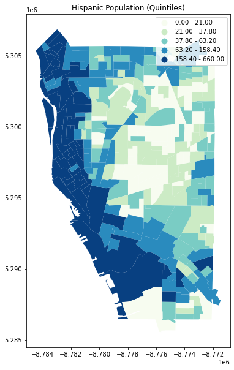

```python
fig, ax = plt.subplots(figsize=(12,10), subplot_kw=dict(aspect='equal'))
bg.plot(column='hispanic', scheme='Quantiles',
        k=5, cmap='GnBu', legend=True, ax=ax);
plt.title("Hispanic Population (Quintiles)");
```

## Queen weights

> Neighbors share an edge or vertex

```python
qW =  lp.weights.Queen.from_dataframe(bg)
qW.transform = 'r' # transform property to row standardize
```

```python
qW
```

```
<libpysal.weights.contiguity.Queen at 0x1e35c98c6c8>
```

```python
qW[72] #neighbors & weights of the 73th observation (0-index remember)
```

```
{108: 0.14285714285714285,
 177: 0.14285714285714285,
 101: 0.14285714285714285,
 134: 0.14285714285714285,
 136: 0.14285714285714285,
 155: 0.14285714285714285,
 140: 0.14285714285714285}
```

```python
self_and_neighbors = [72]
self_and_neighbors.extend(qW.neighbors[72])
print(self_and_neighbors)
```

```
[72, 108, 177, 101, 134, 136, 155, 140]
```

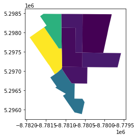

```python
neigh72 =bg.loc[self_and_neighbors]
neigh72.plot(column='hispanic');
```

```python
qW.cardinalities[72] #number of neighbors
```

```
7
```

```python
qW.pct_nonzero #Percentage of nonzero neighbor counts
```

```
2.068739452949532
```

## Spatial Lag

```python
y = bg['hispanic']
ylag = lp.weights.lag_spatial(qW, y)
```

```python
ylag
```

```
array([ 23.8       , 151.33333333,  57.88888889,  24.85714286,
        27.75      ,  22.        ,  42.5       ,  18.2       ,
        37.33333333,  49.8       , 179.5       ,  55.25      ,
        25.        , 255.16666667,  19.8       , 121.        ,
       104.33333333,  41.8       , 293.8       ,  34.        ,
        35.5       ,  33.4       , 300.        ,  69.75      ,
       360.375     ,  29.4       ,  20.25      ,  34.25      ,
       384.        ,  34.11111111, 186.16666667,  48.75      ,
        21.        ,  55.6       ,  38.5       ,  47.        ,
        35.83333333, 178.4       ,  21.5       ,  46.        ,
        98.375     ,  70.6       , 419.5       , 141.66666667,
        66.5       , 276.66666667, 481.28571429,  26.125     ,
        83.625     , 229.14285714, 489.5       ,  25.        ,
       242.16666667, 226.2       ,  19.25      , 156.2       ,
        16.42857143,  56.85714286, 122.        , 215.75      ,
        47.42857143,  78.83333333,  43.        , 235.9       ,
        26.4       ,  32.6       ,  25.25      ,  46.55555556,
        37.        ,  98.6       ,  38.375     ,  21.28571429,
       147.        ,  56.2       , 176.33333333,  19.66666667,
        70.33333333,  23.28571429,  72.        ,  16.71428571,
        19.66666667,  75.66666667,  66.        ,  16.2       ,
        78.75      ,  91.        ,  22.33333333,  52.66666667,
        30.57142857,  20.2       , 241.16666667,  96.5       ,
        69.66666667,  96.33333333,  63.5       , 362.2       ,
       204.66666667,  89.25      ,  30.2       ,  36.        ,
        91.4       , 239.81818182, 494.6       , 123.8       ,
        78.14285714,  82.33333333,  62.2       ,  44.88888889,
       109.28571429, 307.25      ,  19.125     ,  89.85714286,
        56.6       , 112.5       ,  24.375     ,  35.16666667,
        47.4       ,  43.625     , 320.16666667,  64.77777778,
       382.66666667, 199.16666667,  20.125     ,  82.16666667,
       164.75      ,  34.8       ,  96.8       ,  17.4       ,
        79.85714286,  30.33333333,  56.5       ,  59.66666667,
       118.5       ,  43.        ,  66.85714286,  41.57142857,
        63.77777778, 192.5       ,  12.4       ,  50.33333333,
       141.4       ,  50.16666667,  29.5       , 329.66666667,
        21.71428571,  93.        , 127.        , 119.        ,
        37.        , 251.        ,  22.        ,  76.2       ,
        56.5       ,  40.66666667,  26.42857143, 175.        ,
        25.5       , 139.88888889, 357.33333333,  22.        ,
```

[output cut: 17 more lines]

```
        25.        ,  17.375     , 115.6       ,  81.16666667,
       361.33333333,  40.33333333,  51.66666667,  29.8       ,
        48.11111111,  24.83333333, 152.125     ,  81.25      ,
        87.33333333,  18.71428571,  29.        ,  44.        ,
        43.6       ,  86.33333333,  63.14285714,  19.4       ,
       279.25      ,  72.33333333,  27.75      , 117.        ,
       155.        ,  45.25      , 161.        , 411.2       ,
        54.14285714,  33.57142857,  23.8       , 109.22222222,
        61.33333333, 131.        ,  35.        ,  29.54545455,
       391.2       ,  30.57142857,  26.66666667,  90.1       ,
       193.        ,  86.        ,  17.125     ,  32.33333333,
       281.        ,  17.33333333,  28.25      ,  39.8       ,
        19.25      ,  38.        , 395.25      ,  52.        ,
        30.83333333, 214.33333333,  44.77777778,  45.5       ,
        17.44444444,  21.4       , 145.        ])
```

```python
ylagq5 = mc.Quantiles(ylag, k=5) # map classify, method = quantiles, classes = 5
```

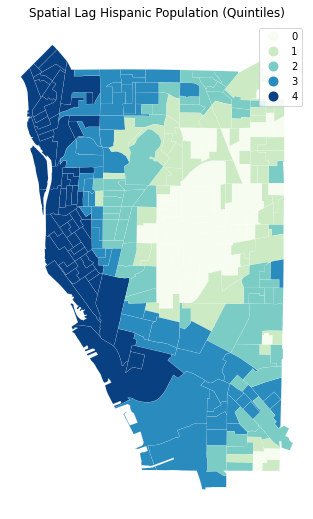

```python
f,ax = plt.subplots(1, figsize=(9, 9), subplot_kw=dict(aspect='equal'))
bg.assign(cl=ylagq5.yb).plot(column='cl', categorical=True,
        k=5, cmap='GnBu', linewidth=0.1,
        edgecolor='white', legend=True, ax=ax)
ax.set_axis_off()
plt.title("Spatial Lag Hispanic Population (Quintiles)")

plt.show()
```

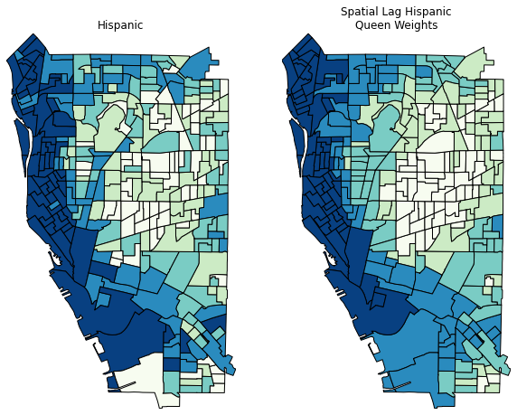

```python
bg['lag_Q_hispanic'] = ylag
f,ax = plt.subplots(1,2,figsize=(10,12), subplot_kw=dict(aspect='equal'))
bg.plot(column='hispanic', ax=ax[0], edgecolor='k',
        scheme="quantiles",  k=5, cmap='GnBu')
ax[0].axis(bg.total_bounds[np.asarray([0,2,1,3])])
ax[0].set_title("Hispanic")
bg.plot(column='lag_Q_hispanic', ax=ax[1], edgecolor='k',
        scheme='quantiles', cmap='GnBu', k=5)
ax[1].axis(bg.total_bounds[np.asarray([0,2,1,3])])
ax[1].set_title("Spatial Lag Hispanic\nQueen Weights")
ax[0].axis('off')
ax[1].axis('off')
plt.show()
```

## Rook weights

> neighbors share an edge

```python
rW = lp.weights.Rook.from_dataframe(bg)
rW.transform = 'r'
```

```python
rW[72]
```

```
{108: 0.2, 177: 0.2, 136: 0.2, 155: 0.2, 140: 0.2}
```

```python
rW.cardinalities[72]
```

```
5
```

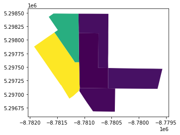

```python
self_and_neighbors = [72]
self_and_neighbors.extend(rW.neighbors[72])
neigh72 =bg.loc[self_and_neighbors]
neigh72.plot(column='hispanic');
```

```python
ylagR = lp.weights.lag_spatial(rW, y)
```

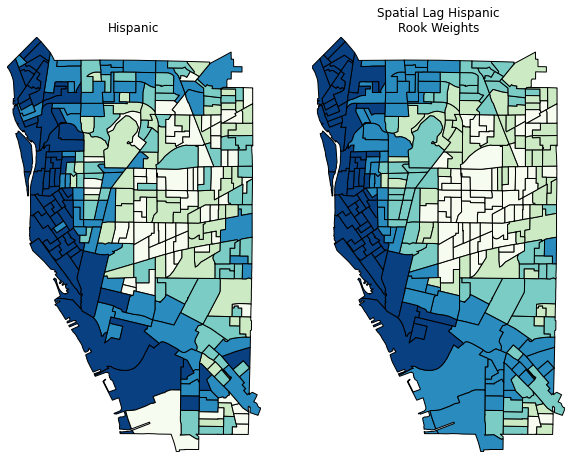

```python
bg['lag_R_hispanic'] = ylagR
f,ax = plt.subplots(1,2,figsize=(10,12), subplot_kw=dict(aspect='equal'))
bg.plot(column='hispanic', ax=ax[0], edgecolor='k',
        scheme="quantiles",  k=5, cmap='GnBu')
ax[0].axis(bg.total_bounds[np.asarray([0,2,1,3])])
ax[0].set_title("Hispanic")
bg.plot(column='lag_R_hispanic', ax=ax[1], edgecolor='k',
        scheme='quantiles', cmap='GnBu', k=5)
ax[1].axis(bg.total_bounds[np.asarray([0,2,1,3])])
ax[1].set_title("Spatial Lag Hispanic\nRook Weights")
ax[0].axis('off')
ax[1].axis('off')
plt.show()
```

## Bishop weights

> share vertex

> Bishop weights entail all Queen neighbor pairs that are not also Rook neighbors.

```python
bW = lp.weights.set_operations.w_difference(qW, rW, constrained=False,silence_warnings=True) #silence because there will be a lot of warnings
bW.transform = 'r'
```

```python
qW.neighbors[72], rW.neighbors[72],bW.neighbors[72]
```

```
([108, 177, 101, 134, 136, 155, 140], [108, 177, 136, 155, 140], [101, 134])
```

```python
bW.histogram
```

```
[(0, 158), (1, 88), (2, 35), (3, 6)]
```

```python
qW.histogram
```

```
[(2, 5),
 (3, 17),
 (4, 38),
 (5, 63),
 (6, 66),
 (7, 42),
 (8, 31),
 (9, 18),
 (10, 3),
 (11, 2),
 (12, 2)]
```

```python
rW.histogram
```

```
[(2, 5),
 (3, 23),
 (4, 62),
 (5, 71),
 (6, 70),
 (7, 34),
 (8, 14),
 (9, 5),
 (10, 2),
 (11, 1)]
```

```python
islands = bW.islands # islands are observations with no neighbors
```

```python
len(islands)
```

```
158
```

```python
bg.query('index not in @islands').head()
```

|  | total_pop | black | geoid10 | hse_units | occup | white | hispanic | geometry | area_o | lag_Q_hispanic | lag_R_hispanic |
| --- | --- | --- | --- | --- | --- | --- | --- | --- | --- | --- | --- |
| 1 | 847 | 196 | 360290164002 | 561 | 365 | 564 | 139 | MULTIPOLYGON (((-8778381.643 5292700.732, -877... | 0.888460 | 151.333333 | 165.600000 |
| 2 | 834 | 54 | 360290054004 | 421 | 402 | 730 | 26 | MULTIPOLYGON (((-8778202.753 5303531.186, -877... | 0.816471 | 57.888889 | 52.142857 |
| 3 | 798 | 768 | 360290033012 | 427 | 334 | 16 | 8 | MULTIPOLYGON (((-8776810.035 5300096.944, -877... | 0.407186 | 24.857143 | 19.666667 |
| 9 | 1009 | 462 | 360290169004 | 334 | 272 | 458 | 106 | MULTIPOLYGON (((-8778356.151 5300134.493, -877... | 0.348803 | 49.800000 | 46.000000 |
| 12 | 921 | 866 | 360290040013 | 529 | 367 | 22 | 11 | MULTIPOLYGON (((-8775856.806 5302875.318, -877... | 0.592925 | 25.000000 | 25.800000 |

```python
ylagB = lp.weights.lag_spatial(bW, y)
```

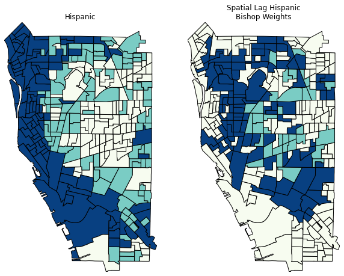

```python
bg['lag_B_hispanic'] = ylagB
f,ax = plt.subplots(1,2,figsize=(10,12), subplot_kw=dict(aspect='equal'))
bg.plot(column='hispanic', ax=ax[0], edgecolor='k',
        scheme="quantiles",  k=3, cmap='GnBu')
ax[0].axis(bg.total_bounds[np.asarray([0,2,1,3])])
ax[0].set_title("Hispanic")
bg.plot(column='lag_B_hispanic', ax=ax[1], edgecolor='k',
        scheme='quantiles', cmap='GnBu', k=3) #changed classes to 3 to avoid class warning
ax[1].axis(bg.total_bounds[np.asarray([0,2,1,3])])
ax[1].set_title("Spatial Lag Hispanic\nBishop Weights")
ax[0].axis('off')
ax[1].axis('off')
plt.show()
```

# Clustering

## Global = Moran's I

Binary case first

```python
y.median() # median number of hispanic population in a block group, defined y in cell 11
```

```
47.0
```

```python
yb = y > y.median()# create binary where number of hispanic in a block group exceeds the median
sum(yb)
```

```
143
```

```python
labels = ["0 Low", "1 High"]
yb = [labels[i] for i in 1*yb]
bg['yb'] = yb
```

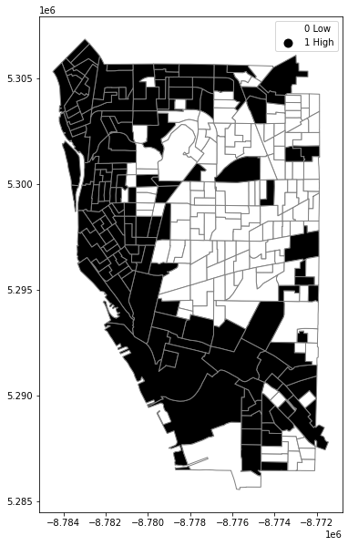

```python
fig = plt.figure(figsize=(12,10))
ax = plt.gca()
bg.plot(column='yb', cmap='binary', edgecolor='grey', legend=True, ax=ax);
```

## Join counts (from scipy 18 lab)

One way to formalize a test for spatial autocorrelation in a binary attribute is to consider the so-called joins. A join exists for each neighbor pair of observations, and the joins are reflected in our binary spatial weights object qW.

Each unit can take on one of two values "Black" or "White", and so for a given pair of neighboring locations there are three different types of joins that can arise:

- Black Black (BB)
- White White (WW)
- Black White (or White Black) (BW)

Given that we have 143 Black polygons on our map, what is the number of Black Black (BB) joins we could expect if the process were such that the Black polygons were randomly assigned on the map? This is the logic of join count statistics.

We can use the esda package from PySAL to carry out join count analysis:

```python
import esda
yb = 1 * (y > y.median()) # convert back to binary
#wq =  lp.weights.Queen.from_dataframe(df)
qW.transform = 'b'
np.random.seed(12345)
jc = esda.join_counts.Join_Counts(yb, qW)
```

```python
jc.bb #number of black/black neighbors
```

```
331
```

```python
jc.ww #number of white/white neighbors
```

```
317
```

```python
jc.bw #number of black/white neighbors
```

```
204
```

from Scipy2018 06 ESDA:

The critical question is whether the number of BB neighbors is a departure from what we would expect if the process generating the spatial distribution of the Black polygons were a completely random one?

To answer this, PySAL uses **random spatial permutations of the observed attribute values** to generate a realization under the null hypothesis of Complete Spatial Randomness (CSR). This is repeated a large number of times (999 default) to construct a reference distribution to evaluate the statistical significance of our observed counts.

The average number of BB joins from the synthetic realizations is:

```python
jc.mean_bb
```

```
210
```

which is less than the observed count = 331. The question is whether the observed value is so different from the expectation that we would reject the null of CSR?

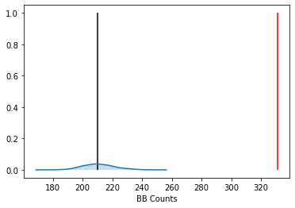

```python
import seaborn as sbn
sbn.kdeplot(jc.sim_bb, shade=True)
plt.vlines(jc.bb, 0, 1, color='r')#red line at observed value
plt.vlines(jc.mean_bb, 0,1)# black line at mean value
plt.xlabel('BB Counts');
```

```python
jc.p_sim_bb #pseudo p-value
```

```
0.001
```

Since this is below conventional significance levels, we would reject the null of complete spatial randomness in favor of spatial autocorrelation in hispanic population residence.

## Continous case

```python
qW.transform = 'r'
```

```python
#np.random.seed(12345)
mi = esda.moran.Moran(y, qW) #
mi.I
```

```
0.793255009505662
```

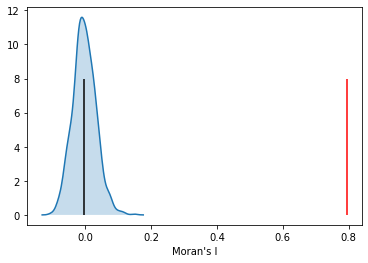

```python
import seaborn as sbn
sbn.kdeplot(mi.sim, shade=True);
plt.vlines(mi.I, 0, 8, color='r');
plt.vlines(mi.EI, 0,8);
plt.xlabel("Moran's I");
```

```python
mi.p_sim # distribution of hispanic population in the city exhibits strong positive Spatial Autocorrelation
```

```
0.001
```

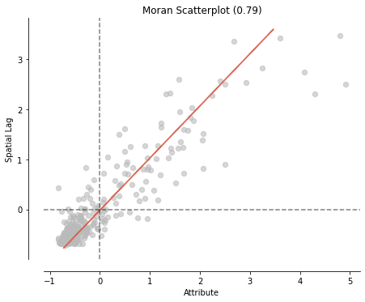

```python
fig, ax = moran_scatterplot(mi, aspect_equal=True)
plt.show()
```

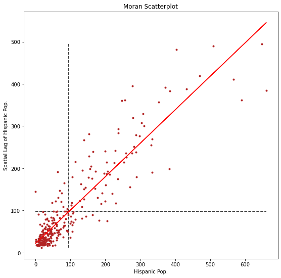

```python
hisp = bg['hispanic']
b, a = np.polyfit(hisp, ylag, 1) #least squares polynomial fit (x,y,degree of the fitting polynomial)
f, ax = plt.subplots(1, figsize=(9, 9))

plt.plot(hisp, ylag, '.', color='firebrick')

 # dashed vert at mean value of hispanic pop
plt.vlines(hisp.mean(), ylag.min(), ylag.max(), linestyle='--')
 # dashed horizontal at mean of lagged pop
plt.hlines(ylag.mean(), hisp.min(), hisp.max(), linestyle='--')

# red line of best fit using global I as slope
plt.plot(hisp, a + b*hisp, 'r')
plt.title('Moran Scatterplot')
plt.ylabel('Spatial Lag of Hispanic Pop.')
plt.xlabel('Hispanic Pop.')
plt.show()
```

# Local Autocorrelation - Hot and Cold Spots, outliers

```python
li = esda.moran.Moran_Local(y, qW) #local I
```

```python
li.q #values indicate quadrat location 1 HH, 2 LH, 3 LL, 4 HL
```

```
array([3, 1, 3, 3, 3, 3, 3, 3, 3, 4, 1, 3, 3, 1, 3, 2, 2, 3, 1, 3, 3, 3,
       1, 3, 1, 3, 3, 3, 1, 3, 1, 3, 3, 3, 3, 3, 3, 1, 3, 3, 2, 3, 1, 1,
       3, 1, 1, 3, 3, 1, 1, 3, 1, 1, 3, 1, 3, 3, 1, 1, 3, 4, 3, 1, 3, 3,
       3, 3, 3, 2, 3, 3, 2, 3, 1, 3, 3, 3, 3, 3, 3, 3, 4, 3, 3, 3, 3, 3,
       3, 3, 1, 2, 3, 1, 3, 1, 1, 3, 3, 3, 3, 1, 1, 1, 3, 3, 3, 3, 2, 1,
       3, 4, 3, 1, 3, 3, 3, 3, 1, 3, 1, 1, 3, 3, 2, 3, 2, 3, 3, 3, 3, 3,
       1, 3, 3, 3, 3, 1, 3, 3, 2, 3, 3, 1, 3, 4, 1, 2, 3, 1, 3, 4, 3, 3,
       3, 1, 3, 1, 1, 3, 3, 1, 3, 2, 3, 3, 3, 3, 3, 4, 3, 4, 3, 3, 3, 1,
       3, 1, 3, 3, 1, 3, 3, 3, 3, 3, 3, 3, 3, 2, 3, 3, 3, 3, 3, 2, 3, 2,
       4, 1, 1, 3, 1, 1, 1, 3, 3, 4, 3, 1, 4, 3, 3, 2, 3, 3, 3, 1, 3, 1,
       3, 3, 1, 1, 1, 4, 3, 3, 3, 3, 1, 3, 1, 3, 3, 3, 3, 3, 1, 3, 3, 3,
       3, 3, 3, 4, 3, 3, 1, 3, 3, 1, 1, 3, 1, 1, 3, 3, 3, 1, 3, 1, 3, 3,
       1, 3, 3, 3, 1, 4, 3, 3, 1, 3, 3, 3, 3, 3, 1, 3, 3, 1, 3, 3, 3, 3,
       2])
```

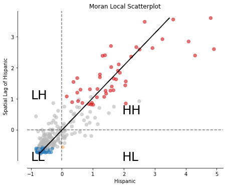

```python
fig, ax = moran_scatterplot(li, p=0.05)
ax.set_xlabel('Hispanic')
ax.set_ylabel('Spatial Lag of Hispanic')
plt.text(1.95, 0.5, 'HH', fontsize=25)
plt.text(1.95, -1.0, 'HL', fontsize=25)
plt.text(-1, 1, 'LH', fontsize=25)
plt.text(-1, -1, 'LL', fontsize=25)
plt.show()
```

```python
(li.p_sim < 0.05).sum() #p value based on permutations < 0.05 - significant at 95%
```

```
122
```

```python
sig = li.p_sim < 0.05 # 95% confidence
hotspot = sig * li.q==1
coldspot = sig * li.q==3
doughnut = sig * li.q==2
diamond = sig * li.q==4
spots = ['n.sig.', 'hot spot']
labels = [spots[i] for i in hotspot*1]
```

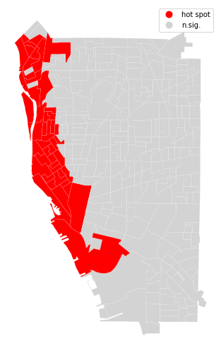

```python
df = bg
from matplotlib import colors
hmap = colors.ListedColormap(['red', 'lightgrey'])
f, ax = plt.subplots(1, figsize=(9, 9))
df.assign(cl=labels).plot(column='cl', categorical=True, \
        k=2, cmap=hmap, linewidth=0.1, ax=ax, \
        edgecolor='white', legend=True)
ax.set_axis_off()
plt.show()
```

```python
spots = ['n.sig.', 'cold spot']
labels = [spots[i] for i in coldspot*1]
```

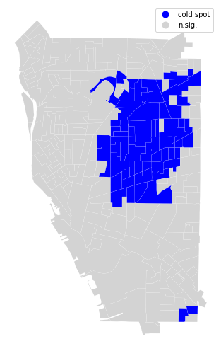

```python
df = bg
from matplotlib import colors
hmap = colors.ListedColormap(['blue', 'lightgrey'])
f, ax = plt.subplots(1, figsize=(9, 9))
df.assign(cl=labels).plot(column='cl', categorical=True, \
        k=2, cmap=hmap, linewidth=0.1, ax=ax, \
        edgecolor='white', legend=True)
ax.set_axis_off()
plt.show()
```